# Machine Learning en aplicaciones espaciales

Mateo W. Racca

06/06/21

# Introducción

El objetivo de esto es recopilar notas de clase y desarrollar una mini guía o resumen sobre machine learning y sus aplicaciones en proyectos (geo)espaciales.

## Modelos

La primera definición de modelo que recuerdo es que los modelos son simplificaciones que nos ayudan a entender, explicar y/o interpretar algo complejo. En el caso de Machine Learning, un modelo es una manera de proponer hipótesis sobre las formas en las que se combinan y relacionan variables.

En general, vamos a ver modelos cuya fórmula general es: **y = f(x) + Ⲉ**

Dónde buscamos estimar *f(x)* para entender de qué forma/s se combinan las equis para generar un output. Podemos suponer que es un modelo lineal o polinómico.

# Desarrollo

En Statistical Modeling: The Two Cultures Breinman sugiere que pensemos en los datos como generados por una caja negra en la que un vector de variables independientes (*x*) está de un lado y del otro se encuentran las variables de respuesta (*y*). En el medio está la caja negra dentro de la cual funciones de la naturaleza asocian las variables predictoras con las de respuesta.

Gráficamente podemos expresarlo de la siguiente manera:

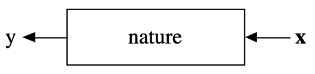

Breiman sostiene que hay dos objetivos en el análisis de datos:

- Predecir respuestas.
- Extraer información sobre cómo la naturaleza relaciona las variables predictoras y las de respuesta.

George Box dijo que todos los modelos son equivocados y que algunos son útiles. Para Breiman hay dos formas de abordar estos objetivos: el modelado de datos y el algorítmico.

## Cultura del Modelado de Datos

El análisis empieza asumiendo un modelo estocástico para la caja negra donde los valores de los parámetros son estimados a partir de los datos y después se realizan las predicciones.

Una forma común es asumir que los datos son generados por extracciones independientes de outputs = *f* (predictores, ruido, parámetros).

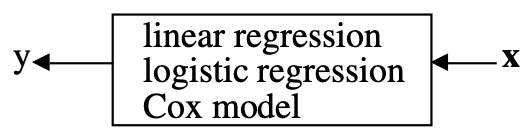

La evaluación del modelo es con estimadores insesgados, robustos y mínima varianza. Este enfoque, según Breiman, agrupa a la mayoría de las/os estadísticas/os.

## Cultura del Modelado Algorítmico

Esta cultura pone énfasis en *y*, es decir en las predicciones. El interior de la caja negra es considerado complejo y desconocido. Busca encontrar una función o algoritmo *f(x)* que opera sobre las *x* para predecir los valores de *y*.

El modelo “aprende”de los datos y la evaluación del mismo depende de su performance predictiva.

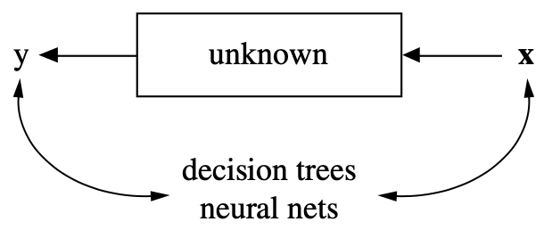